# Simple Forecasting Methods

In this note, we will examine some simple forecasting methods. While these are not likely to be used, they serve as a useful baseline for evaluating more sophisticated models like ARIMA.

```python
import pandas as pd
import numpy as np
import matplotlib.pyplot as plt
```

## Data

To illustrate these methods, we will use monthly international air passenger traffic to Ireland. The last yeer (i.e., 12 months) is set aside as test data.

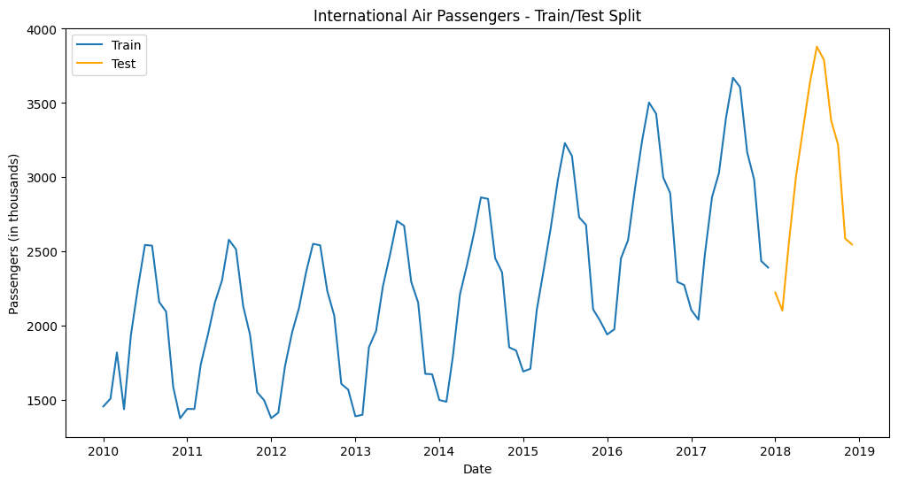

```python
passengers = pd.read_csv('air_passengers.csv',
                 parse_dates = ['date'], date_format='%Y-%m-%d',
                 index_col='date')
passengers = passengers.loc[passengers.name =='Ireland',:]
passengers.columns = [col.lower() for col in passengers.columns]
passengers.head()
passengers = passengers.asfreq('MS')  # Specifies monthly frequency

h = 12
train = passengers.iloc[:-h]
test = passengers.iloc[-h:]

plt.figure(figsize=(12,6))
plt.plot(train.index, train['international'], label='Train')
plt.plot(test.index, test['international'], label='Test', color='orange')
plt.title("International Air Passengers - Train/Test Split")
plt.xlabel("Date")
plt.ylabel("Passengers (in thousands)")
plt.legend()
plt.show()
```

## Average

A very simple prediction, often the baseline in linear regression, is to use the average.

```python
forecasts = test.copy()
forecasts['average'] = train['international'].mean()
from sklearn.metrics import root_mean_squared_error
root_mean_squared_error(test.international, forecasts['average'])
```

```
961.9557059335533
```

## Naive

Use the last observed value as prediction for all future periods.

```python
forecasts['naive'] = train['international'].iloc[-1]
root_mean_squared_error(test.international, forecasts['naive'])
```

```
856.7635031866532
```

## Seasonal Naive

Use the last value from the same season (month) of the previous year as prediction for all future periods.

```python
forecasts['seasonal_naive'] = train['international'].iloc[-12:].values
root_mean_squared_error(test.international, forecasts['seasonal_naive'])
```

```
183.97936526596305
```

## Drift

Allow forecasts to increase or decrease over time, where the amount of change over time (called the drift) is set to be average change seen in historical data.

```python
n = len(train)
drift = (train['international'].iloc[-1] - train['international'].iloc[0]) / (n-1)
forecasts['drift'] = [train['international'].iloc[-1] + (i+1)*drift for i in range(len(test))]
root_mean_squared_error(test.international, forecasts['drift'])
```

```
803.5558799960563
```

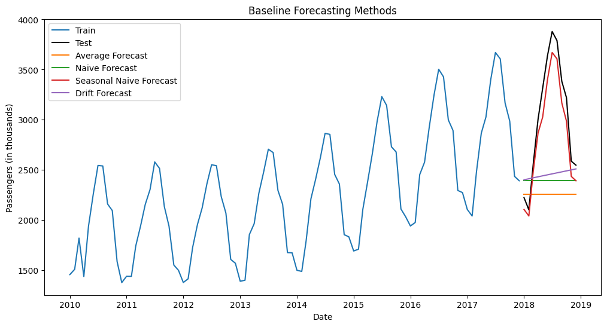

```python
plt.figure(figsize=(12,6))
plt.plot(train.index, train['international'], label='Train')
plt.plot(test.index, test['international'], label='Test', color='black')

plt.plot(test.index, forecasts['average'], label='Average Forecast')
plt.plot(test.index, forecasts['naive'], label='Naive Forecast')
plt.plot(test.index, forecasts['seasonal_naive'], label='Seasonal Naive Forecast')
plt.plot(test.index, forecasts['drift'], label='Drift Forecast')

plt.title("Baseline Forecasting Methods")
plt.xlabel("Date")
plt.ylabel("Passengers (in thousands)")
plt.legend()
plt.show()
```

These forecasting methods illustrate the concept of using historical data to present the future. They also serve as baseline for comparison with more sophisticated models such as ARIMA.

## Summary

In this note, we examined some simple forecasting methods, which are mostly useful as a baseline for evaluating more advanced forecasting methods.

This file was generated using Python 3.13.5 on Windows 10 with the following libraries: matplotlib 3.10.3, numpy 2.3.1, pandas 2.3.0, scikit-learn 1.7.1